# Risk Factor Analysis

## Outcome Variable

**Outcome Variable:** ever_swasted

## Predictor Variables

**Intervention Variable:** feducyrs

**Adjustment Set:**

unadjusted

## Stratifying Variables

The analysis was stratified on these variable(s):

- agecat
- studyid
- country

## Data Summary

| agecat | studyid | country | feducyrs | ever_swasted | n_cell | n |
| --- | --- | --- | --- | --- | --- | --- |
| 0-24 months | ki0047075b-MAL-ED | BANGLADESH | High | 0 | 50 | 147 |
| 0-24 months | ki0047075b-MAL-ED | BANGLADESH | High | 1 | 4 | 147 |
| 0-24 months | ki0047075b-MAL-ED | BANGLADESH | Low | 0 | 33 | 147 |
| 0-24 months | ki0047075b-MAL-ED | BANGLADESH | Low | 1 | 6 | 147 |
| 0-24 months | ki0047075b-MAL-ED | BANGLADESH | Medium | 0 | 49 | 147 |
| 0-24 months | ki0047075b-MAL-ED | BANGLADESH | Medium | 1 | 5 | 147 |
| 0-24 months | ki0047075b-MAL-ED | INDIA | High | 0 | 43 | 147 |
| 0-24 months | ki0047075b-MAL-ED | INDIA | High | 1 | 1 | 147 |
| 0-24 months | ki0047075b-MAL-ED | INDIA | Low | 0 | 51 | 147 |
| 0-24 months | ki0047075b-MAL-ED | INDIA | Low | 1 | 8 | 147 |
| 0-24 months | ki0047075b-MAL-ED | INDIA | Medium | 0 | 37 | 147 |
| 0-24 months | ki0047075b-MAL-ED | INDIA | Medium | 1 | 7 | 147 |
| 0-24 months | ki0047075b-MAL-ED | NEPAL | High | 0 | 40 | 98 |
| 0-24 months | ki0047075b-MAL-ED | NEPAL | High | 1 | 2 | 98 |
| 0-24 months | ki0047075b-MAL-ED | NEPAL | Low | 0 | 28 | 98 |
| 0-24 months | ki0047075b-MAL-ED | NEPAL | Low | 1 | 0 | 98 |
| 0-24 months | ki0047075b-MAL-ED | NEPAL | Medium | 0 | 26 | 98 |
| 0-24 months | ki0047075b-MAL-ED | NEPAL | Medium | 1 | 2 | 98 |
| 0-24 months | ki0047075b-MAL-ED | PERU | High | 0 | 116 | 250 |
| 0-24 months | ki0047075b-MAL-ED | PERU | High | 1 | 4 | 250 |
| 0-24 months | ki0047075b-MAL-ED | PERU | Low | 0 | 69 | 250 |
| 0-24 months | ki0047075b-MAL-ED | PERU | Low | 1 | 0 | 250 |
| 0-24 months | ki0047075b-MAL-ED | PERU | Medium | 0 | 61 | 250 |
| 0-24 months | ki0047075b-MAL-ED | PERU | Medium | 1 | 0 | 250 |
| 0-24 months | ki0047075b-MAL-ED | SOUTH AFRICA | High | 0 | 43 | 110 |
| 0-24 months | ki0047075b-MAL-ED | SOUTH AFRICA | High | 1 | 0 | 110 |
| 0-24 months | ki0047075b-MAL-ED | SOUTH AFRICA | Low | 0 | 32 | 110 |
| 0-24 months | ki0047075b-MAL-ED | SOUTH AFRICA | Low | 1 | 5 | 110 |
| 0-24 months | ki0047075b-MAL-ED | SOUTH AFRICA | Medium | 0 | 30 | 110 |
| 0-24 months | ki0047075b-MAL-ED | SOUTH AFRICA | Medium | 1 | 0 | 110 |

[output cut: 330 more lines]

The following strata were considered:

- agecat: 0-24 months, studyid: ki0047075b-MAL-ED, country: BANGLADESH
- agecat: 0-24 months, studyid: ki0047075b-MAL-ED, country: INDIA
- agecat: 0-24 months, studyid: ki0047075b-MAL-ED, country: NEPAL
- agecat: 0-24 months, studyid: ki0047075b-MAL-ED, country: PERU
- agecat: 0-24 months, studyid: ki0047075b-MAL-ED, country: SOUTH AFRICA
- agecat: 0-24 months, studyid: ki0047075b-MAL-ED, country: TANZANIA, UNITED REPUBLIC OF
- agecat: 0-24 months, studyid: ki1000304b-SAS-CompFeed, country: INDIA
- agecat: 0-24 months, studyid: ki1000304b-SAS-FoodSuppl, country: INDIA
- agecat: 0-24 months, studyid: ki1017093b-PROVIDE, country: BANGLADESH
- agecat: 0-24 months, studyid: ki1017093c-NIH-Crypto, country: BANGLADESH
- agecat: 0-24 months, studyid: ki1066203-TanzaniaChild2, country: TANZANIA, UNITED REPUBLIC OF
- agecat: 0-24 months, studyid: ki1113344-GMS-Nepal, country: NEPAL
- agecat: 0-24 months, studyid: ki1119695-PROBIT, country: BELARUS
- agecat: 0-24 months, studyid: ki1126311-ZVITAMBO, country: ZIMBABWE
- agecat: 0-24 months, studyid: ki1135781-COHORTS, country: GUATEMALA
- agecat: 0-24 months, studyid: ki1135781-COHORTS, country: INDIA
- agecat: 0-24 months, studyid: ki1135781-COHORTS, country: PHILIPPINES
- agecat: 0-24 months, studyid: ki1148112-LCNI-5, country: MALAWI
- agecat: 0-24 months, studyid: kiGH5241-JiVitA-3, country: BANGLADESH
- agecat: 0-24 months, studyid: kiGH5241-JiVitA-4, country: BANGLADESH
- agecat: 0-6 months, studyid: ki0047075b-MAL-ED, country: BANGLADESH
- agecat: 0-6 months, studyid: ki0047075b-MAL-ED, country: INDIA
- agecat: 0-6 months, studyid: ki0047075b-MAL-ED, country: NEPAL
- agecat: 0-6 months, studyid: ki0047075b-MAL-ED, country: PERU
- agecat: 0-6 months, studyid: ki0047075b-MAL-ED, country: SOUTH AFRICA
- agecat: 0-6 months, studyid: ki0047075b-MAL-ED, country: TANZANIA, UNITED REPUBLIC OF
- agecat: 0-6 months, studyid: ki1000304b-SAS-CompFeed, country: INDIA
- agecat: 0-6 months, studyid: ki1000304b-SAS-FoodSuppl, country: INDIA
- agecat: 0-6 months, studyid: ki1017093b-PROVIDE, country: BANGLADESH
- agecat: 0-6 months, studyid: ki1017093c-NIH-Crypto, country: BANGLADESH
- agecat: 0-6 months, studyid: ki1066203-TanzaniaChild2, country: TANZANIA, UNITED REPUBLIC OF
- agecat: 0-6 months, studyid: ki1113344-GMS-Nepal, country: NEPAL
- agecat: 0-6 months, studyid: ki1119695-PROBIT, country: BELARUS
- agecat: 0-6 months, studyid: ki1126311-ZVITAMBO, country: ZIMBABWE
- agecat: 0-6 months, studyid: ki1135781-COHORTS, country: GUATEMALA
- agecat: 0-6 months, studyid: ki1135781-COHORTS, country: INDIA
- agecat: 0-6 months, studyid: ki1135781-COHORTS, country: PHILIPPINES
- agecat: 0-6 months, studyid: ki1148112-LCNI-5, country: MALAWI
- agecat: 0-6 months, studyid: kiGH5241-JiVitA-3, country: BANGLADESH
- agecat: 0-6 months, studyid: kiGH5241-JiVitA-4, country: BANGLADESH
- agecat: 6-24 months, studyid: ki0047075b-MAL-ED, country: BANGLADESH
- agecat: 6-24 months, studyid: ki0047075b-MAL-ED, country: INDIA
- agecat: 6-24 months, studyid: ki0047075b-MAL-ED, country: NEPAL
- agecat: 6-24 months, studyid: ki0047075b-MAL-ED, country: PERU
- agecat: 6-24 months, studyid: ki0047075b-MAL-ED, country: SOUTH AFRICA
- agecat: 6-24 months, studyid: ki0047075b-MAL-ED, country: TANZANIA, UNITED REPUBLIC OF
- agecat: 6-24 months, studyid: ki1000304b-SAS-CompFeed, country: INDIA
- agecat: 6-24 months, studyid: ki1000304b-SAS-FoodSuppl, country: INDIA
- agecat: 6-24 months, studyid: ki1017093b-PROVIDE, country: BANGLADESH
- agecat: 6-24 months, studyid: ki1017093c-NIH-Crypto, country: BANGLADESH
- agecat: 6-24 months, studyid: ki1066203-TanzaniaChild2, country: TANZANIA, UNITED REPUBLIC OF
- agecat: 6-24 months, studyid: ki1113344-GMS-Nepal, country: NEPAL
- agecat: 6-24 months, studyid: ki1119695-PROBIT, country: BELARUS
- agecat: 6-24 months, studyid: ki1126311-ZVITAMBO, country: ZIMBABWE
- agecat: 6-24 months, studyid: ki1135781-COHORTS, country: GUATEMALA
- agecat: 6-24 months, studyid: ki1135781-COHORTS, country: INDIA
- agecat: 6-24 months, studyid: ki1135781-COHORTS, country: PHILIPPINES
- agecat: 6-24 months, studyid: ki1148112-LCNI-5, country: MALAWI
- agecat: 6-24 months, studyid: kiGH5241-JiVitA-3, country: BANGLADESH
- agecat: 6-24 months, studyid: kiGH5241-JiVitA-4, country: BANGLADESH

### Dropped Strata

Some strata were dropped due to rare outcomes:

- agecat: 0-24 months, studyid: ki0047075b-MAL-ED, country: BANGLADESH
- agecat: 0-24 months, studyid: ki0047075b-MAL-ED, country: INDIA
- agecat: 0-24 months, studyid: ki0047075b-MAL-ED, country: NEPAL
- agecat: 0-24 months, studyid: ki0047075b-MAL-ED, country: PERU
- agecat: 0-24 months, studyid: ki0047075b-MAL-ED, country: SOUTH AFRICA
- agecat: 0-24 months, studyid: ki0047075b-MAL-ED, country: TANZANIA, UNITED REPUBLIC OF
- agecat: 0-24 months, studyid: ki1148112-LCNI-5, country: MALAWI
- agecat: 0-6 months, studyid: ki0047075b-MAL-ED, country: BANGLADESH
- agecat: 0-6 months, studyid: ki0047075b-MAL-ED, country: INDIA
- agecat: 0-6 months, studyid: ki0047075b-MAL-ED, country: NEPAL
- agecat: 0-6 months, studyid: ki0047075b-MAL-ED, country: PERU
- agecat: 0-6 months, studyid: ki0047075b-MAL-ED, country: SOUTH AFRICA
- agecat: 0-6 months, studyid: ki0047075b-MAL-ED, country: TANZANIA, UNITED REPUBLIC OF
- agecat: 0-6 months, studyid: ki1148112-LCNI-5, country: MALAWI
- agecat: 6-24 months, studyid: ki0047075b-MAL-ED, country: BANGLADESH
- agecat: 6-24 months, studyid: ki0047075b-MAL-ED, country: INDIA
- agecat: 6-24 months, studyid: ki0047075b-MAL-ED, country: NEPAL
- agecat: 6-24 months, studyid: ki0047075b-MAL-ED, country: PERU
- agecat: 6-24 months, studyid: ki0047075b-MAL-ED, country: SOUTH AFRICA
- agecat: 6-24 months, studyid: ki0047075b-MAL-ED, country: TANZANIA, UNITED REPUBLIC OF
- agecat: 6-24 months, studyid: ki1017093b-PROVIDE, country: BANGLADESH
- agecat: 6-24 months, studyid: ki1017093c-NIH-Crypto, country: BANGLADESH
- agecat: 6-24 months, studyid: ki1119695-PROBIT, country: BELARUS
- agecat: 6-24 months, studyid: ki1148112-LCNI-5, country: MALAWI

## Methods Detail

We’re interested in the causal parameters $E[Y_a]$ for all values of $a \in \mathcal{A}$. These parameters represent the mean outcome if, possibly contrary to fact, we intervened to set all units to have $A=a$. Under the randomization and positivity assumptions, these are identified by the statistical parameters $\psi_a=E_W[E_{Y|A,W}(Y|A=a,W)]$. In addition, we’re interested in the mean of $Y$, $E[Y]$ under no intervention (the observed mean). We will estimate these parameters by using SuperLearner to fit the relevant likelihood factors – $E_{Y|A,W}(Y|A=a,W)$ and $p(A=a|W)$, and then updating our likelihood fit using a joint TMLE.

For unadjusted analyses ($W=\{\}$), initial likelihoods were estimated using Lrnr_glm to estimate the simple $E(Y|A)$ and Lrnr_mean to estimate $p(A)$. For adjusted analyses, a small library containing Lrnr_glmnet, Lrnr_xgboost, and Lrnr_mean was used.

Having estimated these parameters, we will then use the delta method to estimate relative risks and attributable risks relative to a prespecified baseline level of $A$.

# Results Detail

## Results Plots

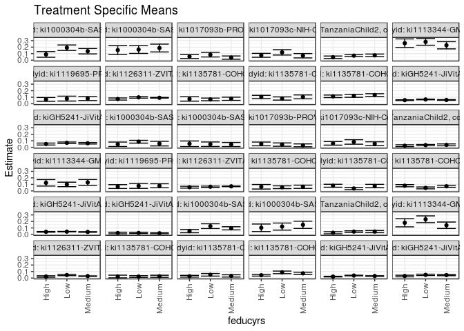

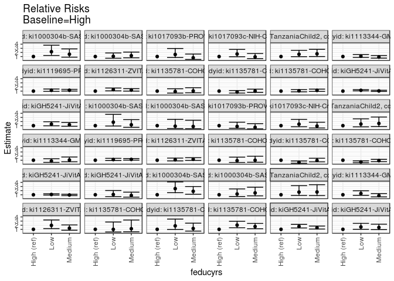

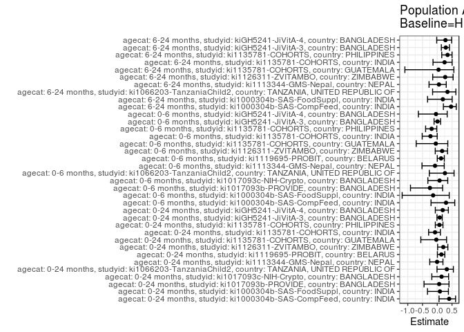

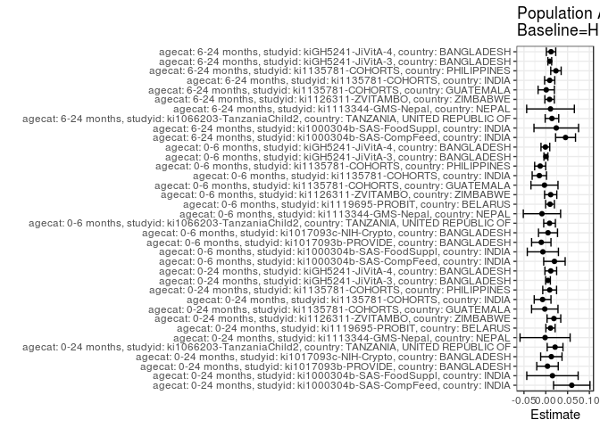

## Results Table

### Parameter: TSM

| agecat | studyid | country | intervention_level | baseline_level | estimate | ci_lower | ci_upper |
| --- | --- | --- | --- | --- | --- | --- | --- |
| 0-24 months | ki1000304b-SAS-CompFeed | INDIA | High | NA | 0.0880829 | 0.0445052 | 0.1316607 |
| 0-24 months | ki1000304b-SAS-CompFeed | INDIA | Low | NA | 0.1912908 | 0.1490863 | 0.2334953 |
| 0-24 months | ki1000304b-SAS-CompFeed | INDIA | Medium | NA | 0.1372141 | 0.0958366 | 0.1785916 |
| 0-24 months | ki1000304b-SAS-FoodSuppl | INDIA | High | NA | 0.1545455 | 0.0869146 | 0.2221763 |
| 0-24 months | ki1000304b-SAS-FoodSuppl | INDIA | Low | NA | 0.1632653 | 0.1034448 | 0.2230859 |
| 0-24 months | ki1000304b-SAS-FoodSuppl | INDIA | Medium | NA | 0.1863354 | 0.1261175 | 0.2465533 |
| 0-24 months | ki1017093b-PROVIDE | BANGLADESH | High | NA | 0.0560345 | 0.0264189 | 0.0856501 |
| 0-24 months | ki1017093b-PROVIDE | BANGLADESH | Low | NA | 0.0840336 | 0.0487611 | 0.1193061 |
| 0-24 months | ki1017093b-PROVIDE | BANGLADESH | Medium | NA | 0.0391304 | 0.0140529 | 0.0642079 |
| 0-24 months | ki1017093c-NIH-Crypto | BANGLADESH | High | NA | 0.0743243 | 0.0444235 | 0.1042252 |
| 0-24 months | ki1017093c-NIH-Crypto | BANGLADESH | Low | NA | 0.1198347 | 0.0788897 | 0.1607797 |
| 0-24 months | ki1017093c-NIH-Crypto | BANGLADESH | Medium | NA | 0.0681818 | 0.0348527 | 0.1015109 |
| 0-24 months | ki1066203-TanzaniaChild2 | TANZANIA, UNITED REPUBLIC OF | High | NA | 0.0445434 | 0.0254575 | 0.0636294 |
| 0-24 months | ki1066203-TanzaniaChild2 | TANZANIA, UNITED REPUBLIC OF | Low | NA | 0.0692913 | 0.0553217 | 0.0832609 |
| 0-24 months | ki1066203-TanzaniaChild2 | TANZANIA, UNITED REPUBLIC OF | Medium | NA | 0.0737952 | 0.0539057 | 0.0936846 |
| 0-24 months | ki1113344-GMS-Nepal | NEPAL | High | NA | 0.2603550 | 0.1941460 | 0.3265640 |
| 0-24 months | ki1113344-GMS-Nepal | NEPAL | Low | NA | 0.2808219 | 0.2292387 | 0.3324051 |
| 0-24 months | ki1113344-GMS-Nepal | NEPAL | Medium | NA | 0.2286996 | 0.1735353 | 0.2838638 |
| 0-24 months | ki1119695-PROBIT | BELARUS | High | NA | 0.0664697 | 0.0368425 | 0.0960969 |
| 0-24 months | ki1119695-PROBIT | BELARUS | Low | NA | 0.0789966 | 0.0414714 | 0.1165217 |
| 0-24 months | ki1119695-PROBIT | BELARUS | Medium | NA | 0.0798442 | 0.0487783 | 0.1109101 |
| 0-24 months | ki1126311-ZVITAMBO | ZIMBABWE | High | NA | 0.0725806 | 0.0564349 | 0.0887263 |
| 0-24 months | ki1126311-ZVITAMBO | ZIMBABWE | Low | NA | 0.0980736 | 0.0858759 | 0.1102712 |
| 0-24 months | ki1126311-ZVITAMBO | ZIMBABWE | Medium | NA | 0.0915274 | 0.0859562 | 0.0970986 |
| 0-24 months | ki1135781-COHORTS | GUATEMALA | High | NA | 0.0735931 | 0.0399080 | 0.1072781 |
| 0-24 months | ki1135781-COHORTS | GUATEMALA | Low | NA | 0.0663082 | 0.0456548 | 0.0869617 |
| 0-24 months | ki1135781-COHORTS | GUATEMALA | Medium | NA | 0.0764045 | 0.0517132 | 0.1010958 |
| 0-24 months | ki1135781-COHORTS | INDIA | High | NA | 0.1040564 | 0.0789155 | 0.1291974 |
| 0-24 months | ki1135781-COHORTS | INDIA | Low | NA | 0.0805085 | 0.0559545 | 0.1050625 |
| 0-24 months | ki1135781-COHORTS | INDIA | Medium | NA | 0.1053922 | 0.0755872 | 0.1351971 |

[output cut: 78 more lines]

### Parameter: E(Y)

| agecat | studyid | country | intervention_level | baseline_level | estimate | ci_lower | ci_upper |
| --- | --- | --- | --- | --- | --- | --- | --- |
| 0-24 months | ki1000304b-SAS-CompFeed | INDIA | NA | NA | 0.1476821 | 0.1188009 | 0.1765633 |
| 0-24 months | ki1000304b-SAS-FoodSuppl | INDIA | NA | NA | 0.1698565 | 0.1338154 | 0.2058975 |
| 0-24 months | ki1017093b-PROVIDE | BANGLADESH | NA | NA | 0.0600000 | 0.0423945 | 0.0776055 |
| 0-24 months | ki1017093c-NIH-Crypto | BANGLADESH | NA | NA | 0.0870712 | 0.0669870 | 0.1071555 |
| 0-24 months | ki1066203-TanzaniaChild2 | TANZANIA, UNITED REPUBLIC OF | NA | NA | 0.0658833 | 0.0559209 | 0.0758458 |
| 0-24 months | ki1113344-GMS-Nepal | NEPAL | NA | NA | 0.2587719 | 0.2259267 | 0.2916172 |
| 0-24 months | ki1119695-PROBIT | BELARUS | NA | NA | 0.0772908 | 0.0449502 | 0.1096314 |
| 0-24 months | ki1126311-ZVITAMBO | ZIMBABWE | NA | NA | 0.0912441 | 0.0863987 | 0.0960895 |
| 0-24 months | ki1135781-COHORTS | GUATEMALA | NA | NA | 0.0713128 | 0.0569485 | 0.0856771 |
| 0-24 months | ki1135781-COHORTS | INDIA | NA | NA | 0.0967519 | 0.0815150 | 0.1119888 |
| 0-24 months | ki1135781-COHORTS | PHILIPPINES | NA | NA | 0.1227336 | 0.1107225 | 0.1347447 |
| 0-24 months | kiGH5241-JiVitA-3 | BANGLADESH | NA | NA | 0.0605314 | 0.0569870 | 0.0640758 |
| 0-24 months | kiGH5241-JiVitA-4 | BANGLADESH | NA | NA | 0.0619670 | 0.0548012 | 0.0691329 |
| 0-6 months | ki1000304b-SAS-CompFeed | INDIA | NA | NA | 0.0665779 | 0.0427569 | 0.0903989 |
| 0-6 months | ki1000304b-SAS-FoodSuppl | INDIA | NA | NA | 0.0478469 | 0.0273607 | 0.0683330 |
| 0-6 months | ki1017093b-PROVIDE | BANGLADESH | NA | NA | 0.0414286 | 0.0266555 | 0.0562017 |
| 0-6 months | ki1017093c-NIH-Crypto | BANGLADESH | NA | NA | 0.0659631 | 0.0482810 | 0.0836451 |
| 0-6 months | ki1066203-TanzaniaChild2 | TANZANIA, UNITED REPUBLIC OF | NA | NA | 0.0331515 | 0.0259618 | 0.0403411 |
| 0-6 months | ki1113344-GMS-Nepal | NEPAL | NA | NA | 0.1154971 | 0.0915268 | 0.1394673 |
| 0-6 months | ki1119695-PROBIT | BELARUS | NA | NA | 0.0758337 | 0.0433525 | 0.1083150 |
| 0-6 months | ki1126311-ZVITAMBO | ZIMBABWE | NA | NA | 0.0681110 | 0.0638575 | 0.0723645 |
| 0-6 months | ki1135781-COHORTS | GUATEMALA | NA | NA | 0.0601805 | 0.0454109 | 0.0749501 |
| 0-6 months | ki1135781-COHORTS | INDIA | NA | NA | 0.0642202 | 0.0514517 | 0.0769887 |
| 0-6 months | ki1135781-COHORTS | PHILIPPINES | NA | NA | 0.0669690 | 0.0578174 | 0.0761205 |
| 0-6 months | kiGH5241-JiVitA-3 | BANGLADESH | NA | NA | 0.0411097 | 0.0380745 | 0.0441448 |
| 0-6 months | kiGH5241-JiVitA-4 | BANGLADESH | NA | NA | 0.0212207 | 0.0163071 | 0.0261342 |
| 6-24 months | ki1000304b-SAS-CompFeed | INDIA | NA | NA | 0.0966811 | 0.0731505 | 0.1202117 |
| 6-24 months | ki1000304b-SAS-FoodSuppl | INDIA | NA | NA | 0.1268657 | 0.0942904 | 0.1594410 |
| 6-24 months | ki1066203-TanzaniaChild2 | TANZANIA, UNITED REPUBLIC OF | NA | NA | 0.0408163 | 0.0321620 | 0.0494707 |
| 6-24 months | ki1113344-GMS-Nepal | NEPAL | NA | NA | 0.1901528 | 0.1584343 | 0.2218713 |
| 6-24 months | ki1126311-ZVITAMBO | ZIMBABWE | NA | NA | 0.0324638 | 0.0290744 | 0.0358532 |
| 6-24 months | ki1135781-COHORTS | GUATEMALA | NA | NA | 0.0248889 | 0.0157815 | 0.0339963 |
| 6-24 months | ki1135781-COHORTS | INDIA | NA | NA | 0.0362989 | 0.0265157 | 0.0460822 |
| 6-24 months | ki1135781-COHORTS | PHILIPPINES | NA | NA | 0.0666667 | 0.0571766 | 0.0761568 |
| 6-24 months | kiGH5241-JiVitA-3 | BANGLADESH | NA | NA | 0.0317355 | 0.0287378 | 0.0347333 |
| 6-24 months | kiGH5241-JiVitA-4 | BANGLADESH | NA | NA | 0.0434288 | 0.0375191 | 0.0493385 |

### Parameter: RR

| agecat | studyid | country | intervention_level | baseline_level | estimate | ci_lower | ci_upper |
| --- | --- | --- | --- | --- | --- | --- | --- |
| 0-24 months | ki1000304b-SAS-CompFeed | INDIA | High | High | 1.0000000 | 1.0000000 | 1.0000000 |
| 0-24 months | ki1000304b-SAS-CompFeed | INDIA | Low | High | 2.1717135 | 1.2591127 | 3.7457644 |
| 0-24 months | ki1000304b-SAS-CompFeed | INDIA | Medium | High | 1.5577840 | 0.8510236 | 2.8514968 |
| 0-24 months | ki1000304b-SAS-FoodSuppl | INDIA | High | High | 1.0000000 | 1.0000000 | 1.0000000 |
| 0-24 months | ki1000304b-SAS-FoodSuppl | INDIA | Low | High | 1.0564226 | 0.5969870 | 1.8694355 |
| 0-24 months | ki1000304b-SAS-FoodSuppl | INDIA | Medium | High | 1.2056997 | 0.6998104 | 2.0772937 |
| 0-24 months | ki1017093b-PROVIDE | BANGLADESH | High | High | 1.0000000 | 1.0000000 | 1.0000000 |
| 0-24 months | ki1017093b-PROVIDE | BANGLADESH | Low | High | 1.4996768 | 0.7636284 | 2.9451898 |
| 0-24 months | ki1017093b-PROVIDE | BANGLADESH | Medium | High | 0.6983278 | 0.3042943 | 1.6025988 |
| 0-24 months | ki1017093c-NIH-Crypto | BANGLADESH | High | High | 1.0000000 | 1.0000000 | 1.0000000 |
| 0-24 months | ki1017093c-NIH-Crypto | BANGLADESH | Low | High | 1.6123216 | 0.9510936 | 2.7332544 |
| 0-24 months | ki1017093c-NIH-Crypto | BANGLADESH | Medium | High | 0.9173554 | 0.4870702 | 1.7277609 |
| 0-24 months | ki1066203-TanzaniaChild2 | TANZANIA, UNITED REPUBLIC OF | High | High | 1.0000000 | 1.0000000 | 1.0000000 |
| 0-24 months | ki1066203-TanzaniaChild2 | TANZANIA, UNITED REPUBLIC OF | Low | High | 1.5555905 | 0.9688125 | 2.4977608 |
| 0-24 months | ki1066203-TanzaniaChild2 | TANZANIA, UNITED REPUBLIC OF | Medium | High | 1.6567018 | 0.9986314 | 2.7484221 |
| 0-24 months | ki1113344-GMS-Nepal | NEPAL | High | High | 1.0000000 | 1.0000000 | 1.0000000 |
| 0-24 months | ki1113344-GMS-Nepal | NEPAL | Low | High | 1.0786115 | 0.7881789 | 1.4760641 |
| 0-24 months | ki1113344-GMS-Nepal | NEPAL | Medium | High | 0.8784142 | 0.6186976 | 1.2471546 |
| 0-24 months | ki1119695-PROBIT | BELARUS | High | High | 1.0000000 | 1.0000000 | 1.0000000 |
| 0-24 months | ki1119695-PROBIT | BELARUS | Low | High | 1.1884595 | 0.9395246 | 1.5033519 |
| 0-24 months | ki1119695-PROBIT | BELARUS | Medium | High | 1.2012117 | 1.0097954 | 1.4289128 |
| 0-24 months | ki1126311-ZVITAMBO | ZIMBABWE | High | High | 1.0000000 | 1.0000000 | 1.0000000 |
| 0-24 months | ki1126311-ZVITAMBO | ZIMBABWE | Low | High | 1.3512356 | 1.0472418 | 1.7434729 |
| 0-24 months | ki1126311-ZVITAMBO | ZIMBABWE | Medium | High | 1.2610442 | 1.0013118 | 1.5881491 |
| 0-24 months | ki1135781-COHORTS | GUATEMALA | High | High | 1.0000000 | 1.0000000 | 1.0000000 |
| 0-24 months | ki1135781-COHORTS | GUATEMALA | Low | High | 0.9010120 | 0.5179460 | 1.5673887 |
| 0-24 months | ki1135781-COHORTS | GUATEMALA | Medium | High | 1.0382022 | 0.5928482 | 1.8181111 |
| 0-24 months | ki1135781-COHORTS | INDIA | High | High | 1.0000000 | 1.0000000 | 1.0000000 |
| 0-24 months | ki1135781-COHORTS | INDIA | Low | High | 0.7737001 | 0.5243156 | 1.1417013 |
| 0-24 months | ki1135781-COHORTS | INDIA | Medium | High | 1.0128365 | 0.6982342 | 1.4691887 |

[output cut: 78 more lines]

### Parameter: PAR

| agecat | studyid | country | intervention_level | baseline_level | estimate | ci_lower | ci_upper |
| --- | --- | --- | --- | --- | --- | --- | --- |
| 0-24 months | ki1000304b-SAS-CompFeed | INDIA | High | NA | 0.0595992 | 0.0178521 | 0.1013464 |
| 0-24 months | ki1000304b-SAS-FoodSuppl | INDIA | High | NA | 0.0153110 | -0.0435580 | 0.0741800 |
| 0-24 months | ki1017093b-PROVIDE | BANGLADESH | High | NA | 0.0039655 | -0.0206446 | 0.0285756 |
| 0-24 months | ki1017093c-NIH-Crypto | BANGLADESH | High | NA | 0.0127469 | -0.0117311 | 0.0372250 |
| 0-24 months | ki1066203-TanzaniaChild2 | TANZANIA, UNITED REPUBLIC OF | High | NA | 0.0213399 | 0.0032775 | 0.0394024 |
| 0-24 months | ki1113344-GMS-Nepal | NEPAL | High | NA | -0.0015831 | -0.0589962 | 0.0558300 |
| 0-24 months | ki1119695-PROBIT | BELARUS | High | NA | 0.0108211 | 0.0002261 | 0.0214162 |
| 0-24 months | ki1126311-ZVITAMBO | ZIMBABWE | High | NA | 0.0186635 | 0.0029777 | 0.0343492 |
| 0-24 months | ki1135781-COHORTS | GUATEMALA | High | NA | -0.0022803 | -0.0325491 | 0.0279885 |
| 0-24 months | ki1135781-COHORTS | INDIA | High | NA | -0.0073045 | -0.0265109 | 0.0119019 |
| 0-24 months | ki1135781-COHORTS | PHILIPPINES | High | NA | 0.0089204 | -0.0069230 | 0.0247637 |
| 0-24 months | kiGH5241-JiVitA-3 | BANGLADESH | High | NA | 0.0051045 | -0.0002994 | 0.0105084 |
| 0-24 months | kiGH5241-JiVitA-4 | BANGLADESH | High | NA | 0.0114458 | -0.0020230 | 0.0249146 |
| 0-6 months | ki1000304b-SAS-CompFeed | INDIA | High | NA | 0.0198246 | -0.0047758 | 0.0444251 |
| 0-6 months | ki1000304b-SAS-FoodSuppl | INDIA | High | NA | -0.0066986 | -0.0424031 | 0.0290059 |
| 0-6 months | ki1017093b-PROVIDE | BANGLADESH | High | NA | -0.0102956 | -0.0324867 | 0.0118956 |
| 0-6 months | ki1017093c-NIH-Crypto | BANGLADESH | High | NA | 0.0051522 | -0.0166466 | 0.0269511 |
| 0-6 months | ki1066203-TanzaniaChild2 | TANZANIA, UNITED REPUBLIC OF | High | NA | 0.0086526 | -0.0047325 | 0.0220377 |
| 0-6 months | ki1113344-GMS-Nepal | NEPAL | High | NA | -0.0087633 | -0.0515141 | 0.0339876 |
| 0-6 months | ki1119695-PROBIT | BELARUS | High | NA | 0.0097333 | -0.0003203 | 0.0197869 |
| 0-6 months | ki1126311-ZVITAMBO | ZIMBABWE | High | NA | 0.0112582 | -0.0027653 | 0.0252817 |
| 0-6 months | ki1135781-COHORTS | GUATEMALA | High | NA | -0.0029774 | -0.0339486 | 0.0279939 |
| 0-6 months | ki1135781-COHORTS | INDIA | High | NA | -0.0147744 | -0.0312184 | 0.0016695 |
| 0-6 months | ki1135781-COHORTS | PHILIPPINES | High | NA | -0.0127976 | -0.0255007 | -0.0000944 |
| 0-6 months | kiGH5241-JiVitA-3 | BANGLADESH | High | NA | 0.0003345 | -0.0041878 | 0.0048567 |
| 0-6 months | kiGH5241-JiVitA-4 | BANGLADESH | High | NA | -0.0009070 | -0.0109590 | 0.0091451 |
| 6-24 months | ki1000304b-SAS-CompFeed | INDIA | High | NA | 0.0453297 | 0.0224990 | 0.0681605 |
| 6-24 months | ki1000304b-SAS-FoodSuppl | INDIA | High | NA | 0.0240619 | -0.0270616 | 0.0751855 |
| 6-24 months | ki1066203-TanzaniaChild2 | TANZANIA, UNITED REPUBLIC OF | High | NA | 0.0141497 | -0.0013940 | 0.0296933 |
| 6-24 months | ki1113344-GMS-Nepal | NEPAL | High | NA | 0.0108425 | -0.0438250 | 0.0655099 |
| 6-24 months | ki1126311-ZVITAMBO | ZIMBABWE | High | NA | 0.0087539 | -0.0021358 | 0.0196436 |
| 6-24 months | ki1135781-COHORTS | GUATEMALA | High | NA | 0.0010794 | -0.0176188 | 0.0197775 |
| 6-24 months | ki1135781-COHORTS | INDIA | High | NA | 0.0089765 | -0.0027014 | 0.0206544 |
| 6-24 months | ki1135781-COHORTS | PHILIPPINES | High | NA | 0.0233297 | 0.0113857 | 0.0352737 |
| 6-24 months | kiGH5241-JiVitA-3 | BANGLADESH | High | NA | 0.0091894 | 0.0048476 | 0.0135312 |
| 6-24 months | kiGH5241-JiVitA-4 | BANGLADESH | High | NA | 0.0121035 | 0.0013923 | 0.0228147 |

### Parameter: PAF

| agecat | studyid | country | intervention_level | baseline_level | estimate | ci_lower | ci_upper |
| --- | --- | --- | --- | --- | --- | --- | --- |
| 0-24 months | ki1000304b-SAS-CompFeed | INDIA | High | NA | 0.4035642 | 0.0600654 | 0.6215315 |
| 0-24 months | ki1000304b-SAS-FoodSuppl | INDIA | High | NA | 0.0901408 | -0.3312088 | 0.3781264 |
| 0-24 months | ki1017093b-PROVIDE | BANGLADESH | High | NA | 0.0660920 | -0.4482931 | 0.3977847 |
| 0-24 months | ki1017093c-NIH-Crypto | BANGLADESH | High | NA | 0.1463964 | -0.1841883 | 0.3846932 |
| 0-24 months | ki1066203-TanzaniaChild2 | TANZANIA, UNITED REPUBLIC OF | High | NA | 0.3239045 | -0.0082177 | 0.5466206 |
| 0-24 months | ki1113344-GMS-Nepal | NEPAL | High | NA | -0.0061177 | -0.2543495 | 0.1929897 |
| 0-24 months | ki1119695-PROBIT | BELARUS | High | NA | 0.1400052 | 0.0053424 | 0.2564365 |
| 0-24 months | ki1126311-ZVITAMBO | ZIMBABWE | High | NA | 0.2045443 | 0.0130028 | 0.3589143 |
| 0-24 months | ki1135781-COHORTS | GUATEMALA | High | NA | -0.0319756 | -0.5569595 | 0.3159914 |
| 0-24 months | ki1135781-COHORTS | INDIA | High | NA | -0.0754976 | -0.2931812 | 0.1055429 |
| 0-24 months | ki1135781-COHORTS | PHILIPPINES | High | NA | 0.0726808 | -0.0656561 | 0.1930597 |
| 0-24 months | kiGH5241-JiVitA-3 | BANGLADESH | High | NA | 0.0843279 | -0.0090716 | 0.1690825 |
| 0-24 months | kiGH5241-JiVitA-4 | BANGLADESH | High | NA | 0.1847075 | -0.0655102 | 0.3761657 |
| 0-6 months | ki1000304b-SAS-CompFeed | INDIA | High | NA | 0.2977662 | -0.2111830 | 0.5928507 |
| 0-6 months | ki1000304b-SAS-FoodSuppl | INDIA | High | NA | -0.1400000 | -1.1896424 | 0.4064785 |
| 0-6 months | ki1017093b-PROVIDE | BANGLADESH | High | NA | -0.2485137 | -0.9073454 | 0.1827456 |
| 0-6 months | ki1017093c-NIH-Crypto | BANGLADESH | High | NA | 0.0781081 | -0.3185292 | 0.3554298 |
| 0-6 months | ki1066203-TanzaniaChild2 | TANZANIA, UNITED REPUBLIC OF | High | NA | 0.2610019 | -0.2696929 | 0.5698817 |
| 0-6 months | ki1113344-GMS-Nepal | NEPAL | High | NA | -0.0758745 | -0.5173303 | 0.2371431 |
| 0-6 months | ki1119695-PROBIT | BELARUS | High | NA | 0.1283505 | 0.0007139 | 0.2396844 |
| 0-6 months | ki1126311-ZVITAMBO | ZIMBABWE | High | NA | 0.1652920 | -0.0679245 | 0.3475780 |
| 0-6 months | ki1135781-COHORTS | GUATEMALA | High | NA | -0.0494737 | -0.7135175 | 0.3572316 |
| 0-6 months | ki1135781-COHORTS | INDIA | High | NA | -0.2300590 | -0.5105114 | -0.0016774 |
| 0-6 months | ki1135781-COHORTS | PHILIPPINES | High | NA | -0.1910972 | -0.3949698 | -0.0170202 |
| 0-6 months | kiGH5241-JiVitA-3 | BANGLADESH | High | NA | 0.0081357 | -0.1081542 | 0.1122222 |
| 0-6 months | kiGH5241-JiVitA-4 | BANGLADESH | High | NA | -0.0427396 | -0.6399924 | 0.3370055 |
| 6-24 months | ki1000304b-SAS-CompFeed | INDIA | High | NA | 0.4688584 | 0.2075767 | 0.6439890 |
| 6-24 months | ki1000304b-SAS-FoodSuppl | INDIA | High | NA | 0.1896646 | -0.3287005 | 0.5058003 |
| 6-24 months | ki1066203-TanzaniaChild2 | TANZANIA, UNITED REPUBLIC OF | High | NA | 0.3466667 | -0.1582084 | 0.6314614 |
| 6-24 months | ki1113344-GMS-Nepal | NEPAL | High | NA | 0.0570197 | -0.2789933 | 0.3047565 |
| 6-24 months | ki1126311-ZVITAMBO | ZIMBABWE | High | NA | 0.2696516 | -0.1543240 | 0.5379037 |
| 6-24 months | ki1135781-COHORTS | GUATEMALA | High | NA | 0.0433673 | -1.0976561 | 0.5637292 |
| 6-24 months | ki1135781-COHORTS | INDIA | High | NA | 0.2472945 | -0.1440653 | 0.5047787 |
| 6-24 months | ki1135781-COHORTS | PHILIPPINES | High | NA | 0.3499458 | 0.1520489 | 0.5016570 |
| 6-24 months | kiGH5241-JiVitA-3 | BANGLADESH | High | NA | 0.2895620 | 0.1387473 | 0.4139674 |
| 6-24 months | kiGH5241-JiVitA-4 | BANGLADESH | High | NA | 0.2786973 | -0.0187264 | 0.4892863 |